# Machine Learning Project

Junaid Khan

May 26, 2018

## Background

Using devices such as Jawbone Up, Nike FuelBand, and Fitbit it is now possible to collect a large amount of data about personal activity relatively inexpensively. These type of devices are part of the quantified self movement - a group of enthusiasts who take measurements about themselves regularly to improve their health, to find patterns in their behavior, or because they are tech geeks. One thing that people regularly do is quantify how much of a particular activity they do, but they rarely quantify how well they do it. In this project, your goal will be to use data from accelerometers on the belt, forearm, arm, and dumbell of 6 participants. They were asked to perform barbell lifts correctly and incorrectly in 5 different ways.

## Libraries

```r
library(caret)
library(rpart)
library(rattle)
```

### Reading the Train and Test csv files

```r
Training <- read.csv("pml-training.csv")
Testing <- read.csv("pml-testing.csv")
```

Looking at the Training Data strucutre

```r
str(Training)
```

```
## 'data.frame':    19622 obs. of  160 variables:
##  $ X                       : int  1 2 3 4 5 6 7 8 9 10 ...
##  $ user_name               : Factor w/ 6 levels "adelmo","carlitos",..: 2 2 2 2 2 2 2 2 2 2 ...
##  $ raw_timestamp_part_1    : int  1323084231 1323084231 1323084231 1323084232 1323084232 1323084232 1323084232 1323084232 1323084232 1323084232 ...
##  $ raw_timestamp_part_2    : int  788290 808298 820366 120339 196328 304277 368296 440390 484323 484434 ...
##  $ cvtd_timestamp          : Factor w/ 20 levels "02/12/2011 13:32",..: 9 9 9 9 9 9 9 9 9 9 ...
##  $ new_window              : Factor w/ 2 levels "no","yes": 1 1 1 1 1 1 1 1 1 1 ...
##  $ num_window              : int  11 11 11 12 12 12 12 12 12 12 ...
##  $ roll_belt               : num  1.41 1.41 1.42 1.48 1.48 1.45 1.42 1.42 1.43 1.45 ...
##  $ pitch_belt              : num  8.07 8.07 8.07 8.05 8.07 8.06 8.09 8.13 8.16 8.17 ...
##  $ yaw_belt                : num  -94.4 -94.4 -94.4 -94.4 -94.4 -94.4 -94.4 -94.4 -94.4 -94.4 ...
##  $ total_accel_belt        : int  3 3 3 3 3 3 3 3 3 3 ...
##  $ kurtosis_roll_belt      : Factor w/ 397 levels "","-0.016850",..: 1 1 1 1 1 1 1 1 1 1 ...
##  $ kurtosis_picth_belt     : Factor w/ 317 levels "","-0.021887",..: 1 1 1 1 1 1 1 1 1 1 ...
##  $ kurtosis_yaw_belt       : Factor w/ 2 levels "","#DIV/0!": 1 1 1 1 1 1 1 1 1 1 ...
```

[output cut: 86 more lines]

The training data set is made of 19622 observations on 160 columns. We can notice that many columns have NA values or blank values on almost every observation. So we will remove them, because they will not produce any information. The first seven columns give information about the people who did the test, and also timestamps. We will not take them in our model.

### Here we get the indexes of the columns having at least 90% of NA or blank values on the training dataset

```r
Training <- read.csv("pml-training.csv")
colToRemove <- which(colSums(is.na(Training) | Training =="")> 0.9*dim(Training)[1])
TrainingClean <- Training[,-colToRemove]
TrainingClean <- TrainingClean[,-c(1:7)]
dim(TrainingClean)
```

```
## [1] 19622    53
```

### Do the same for Testing Data

```r
Testing <- read.csv("pml-testing.csv")
colToRemove <- which(colSums(is.na(Testing) | Testing =="") > 0.9*dim(Testing)[1])
TestingClean <- Testing[,-colToRemove]
TestingClean <- TestingClean[,-1]
```

```r
# Here we create a partition of the training data set
set.seed(12345)
inTrain1 <- createDataPartition(TrainingClean$classe, p=0.75, list=FALSE)
Train1 <- TrainingClean[inTrain1,]
Test1 <- TrainingClean[-inTrain1,]
dim(Train1)
```

```
## [1] 14718    53
```

```r
dim(Test1)
```

```
## [1] 4904   53
```

In the following sections, we will test 3 different models : Classification Tree, Random Forest and Gradient Boosting

### Train with Classification Tree

```r
# define training control
train_control<- trainControl(method="cv", number=10)
```

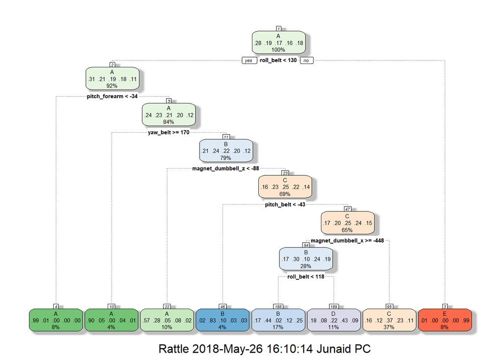

```r
  # Building the classifier
model1 <- train(classe ~ . ,data = Train1, trControl = train_control, method="rpart")


 # Plot Classification Tree
fancyRpartPlot(model1$finalModel)
```

```r
  # Predicting With Classification Tree
trainpred <- predict(model1, newdata = Test1)

  #Building Confusion Matrix

confusion_CT <- confusionMatrix(Test1$classe,trainpred)
confusion_CT$table
```

```
##           Reference
## Prediction   A   B   C   D   E
##          A 870 159 273  88   5
##          B 162 530 214  43   0
##          C  29  36 674 116   0
##          D  46 136 429 193   0
##          E  16 221 224  51 389
```

```r
confusion_CT$overall[1]
```

```
##  Accuracy
## 0.5415987
```

We can notice that the accuracy is **very low ( around 55 %)**. Thus this model wont be appropriate to make prediction.

## Train with Random Forest

```r
  #Building the classifier
model2 <- train(classe~., data=Train1, method="rf", trControl=train_control, verbose=FALSE)
```

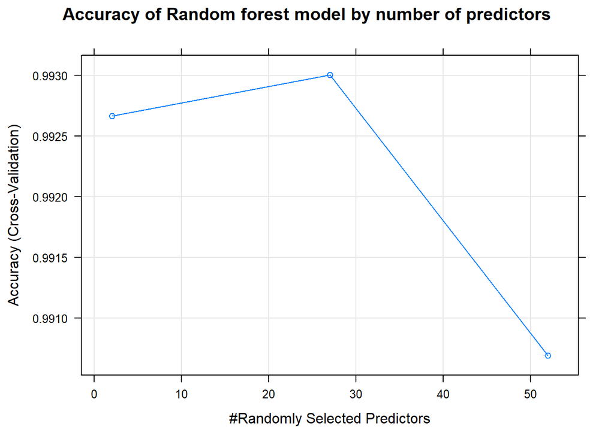

```r
  # Plotting
plot(model2,main="Accuracy of Random forest model by number of predictors")
```

```r
  # Predicting with Random forest
trainpred2 <- predict(model2, newdata = Test1)

  #Building the Confusion Matrix
confusion_RF <- confusionMatrix(Test1$classe,trainpred2)
confusion_RF$table
```

```
##           Reference
## Prediction    A    B    C    D    E
##          A 1394    1    0    0    0
##          B    6  938    5    0    0
##          C    0    3  848    4    0
##          D    0    0   10  794    0
##          E    0    0    2    5  894
```

```r
confusion_RF$overall[1]
```

```
##  Accuracy
## 0.9926591
```

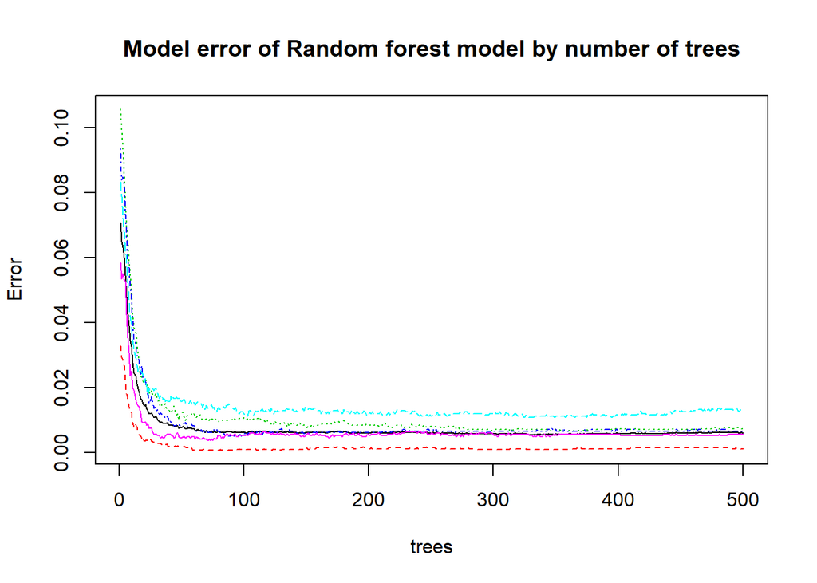

```r
  #Model Error Plot
plot(model2$finalModel,main="Model error of Random forest model by number of trees")
```

```r
  #Compute the variable importance
MostImpVars <- varImp(model2)
MostImpVars
```

```
## rf variable importance
##
##   only 20 most important variables shown (out of 52)
##
##                      Overall
## roll_belt            100.000
## pitch_forearm         57.818
## yaw_belt              55.891
## magnet_dumbbell_z     43.578
## pitch_belt            42.443
## magnet_dumbbell_y     40.594
## roll_forearm          40.078
## accel_dumbbell_y      22.041
## roll_dumbbell         18.152
## magnet_dumbbell_x     17.804
## accel_forearm_x       16.574
## magnet_belt_z         14.882
## accel_dumbbell_z      14.784
## magnet_forearm_z      13.605
## accel_belt_z          13.116
## total_accel_dumbbell  13.042
## magnet_belt_y         12.619
## yaw_arm               10.984
## magnet_belt_x         10.119
## gyros_belt_z           9.915
```

We can also notice that the optimal number of predictors, i.e. the number of predictors giving the highest accuracy, is 27. There is no significal increase of the accuracy with 2 predictors and 27, but the slope decreases more with more than 27 predictors (even if the accuracy is still very good). The fact that not all the accuracy is worse with all the available predictors lets us suggest that there may be some dependencies between them.

## Train with Gradient Boosting

```r
  # Building the classifier
model3 <- train(classe~., data=Train1, method="gbm", trControl=train_control, verbose=FALSE)
print(model3)
```

```
## Stochastic Gradient Boosting
##
## 14718 samples
##    52 predictor
##     5 classes: 'A', 'B', 'C', 'D', 'E'
##
## No pre-processing
## Resampling: Cross-Validated (10 fold)
## Summary of sample sizes: 13247, 13248, 13245, 13246, 13247, 13246, ...
## Resampling results across tuning parameters:
##
##   interaction.depth  n.trees  Accuracy   Kappa
##   1                   50      0.7526797  0.6866327
##   1                  100      0.8185879  0.7703927
##   1                  150      0.8546019  0.8160286
##   2                   50      0.8556195  0.8170329
##   2                  100      0.9075283  0.8829631
##   2                  150      0.9330076  0.9152155
##   3                   50      0.8960463  0.8683874
##   3                  100      0.9420451  0.9266678
##   3                  150      0.9631744  0.9534058
##
## Tuning parameter 'shrinkage' was held constant at a value of 0.1
##
## Tuning parameter 'n.minobsinnode' was held constant at a value of 10
## Accuracy was used to select the optimal model using the largest value.
## The final values used for the model were n.trees = 150,
##  interaction.depth = 3, shrinkage = 0.1 and n.minobsinnode = 10.
```

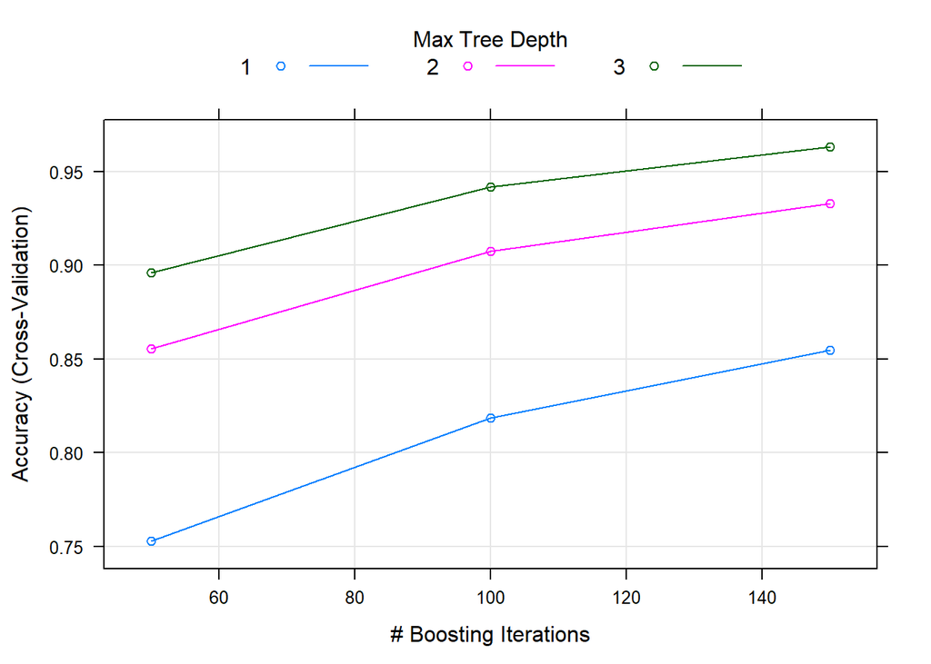

```r
  #plotting the classifier
plot(model3)
```

```r
  #Predicting with Gradient Boosting
trainpred3 <- predict(model3, newdata = Test1)
confusion_GB <- confusionMatrix(Test1$classe,trainpred3)
confusion_GB$table
```

```
##           Reference
## Prediction    A    B    C    D    E
##          A 1375   15    4    1    0
##          B   39  877   29    3    1
##          C    0   17  824   13    1
##          D    0    4   31  767    2
##          E    2    9   11   16  863
```

```r
confusion_GB$overall[1]
```

```
##  Accuracy
## 0.9596248
```

## Conclusion :

Thus we observe that **Random Forest is the best model with 99% accuracy.** We will use this model to predict the values of the classe for the test set.

```r
testpred <- predict(model2, newdata=TestingClean)
testpred
```

```
##  [1] B A B A A E D B A A B C B A E E A B B B
## Levels: A B C D E
```